# MATH 5960 Assignment2

### Constributors

- Jingyi Ni (5229807)
- Xinyue Wang (5002735)
- Yiwei Wang (5226946)
- Tong Wang (5237902)

This report is the programming part of MATH5960 Assignment2.

### Question1

Code a Gibbs sampler with `N = 10000` simulations and with a burnin of 1000 values;

Firstly, we load the observation data and initialize hyperparameters of prior distributions.

```r
library(ggplot2)
library(dplyr)
y <- c(4, 5, 4, 1, 0, 4, 3, 4, 0, 6,
3, 3, 4, 0, 2, 6, 3, 3, 5, 4, 5, 3, 1, 4, 4, 1, 5, 5, 3, 4, 2, 5, 2, 2, 3, 4, 2, 1, 3, 2,
1, 1, 1, 1, 1, 3, 0, 0, 1, 0, 1, 1, 0, 0, 3, 1, 0, 3, 2, 2, 0, 1, 1, 1, 0, 1, 0, 1, 0, 0,
0, 2, 1, 0, 0, 0, 1, 1, 0, 2, 2, 3, 1, 1, 2, 1, 1, 1, 1, 2, 4, 2, 0, 0, 0, 1, 4, 0, 0, 0,
1, 0, 0, 0, 0, 0, 1, 0, 0, 1, 0, 0)
n = length(y)
burnin=1000
alpha = 0.5
a = 0.5
beta =0.5
b = 0.5
Nsim = 10000
```

Then we get the cumulative summation of observation `y` for later use.

```r
sum_y = cumsum(y)
```

Initialize empty vectors for `\lambda, \phi and m` and sample the starting values:

```r
lambda = phi = m = rep(0, Nsim) #init arrays
m[1] = 60
lambda[1] = rgamma(1, shape = alpha + sum_y[m[1]], rate = m[1] + beta)
phi[1] = rgamma(1, shape = a + sum_y[n] - sum_y[m[1]], rate = n - m[1] + b)
```

The full conditional distribution of $\lambda$ and $\phi$ are:

$$\pi(\lambda|y) \propto e^{-(m+\beta)\lambda}\lambda^{\alpha +\sum_{i=1}^m y_i -1} \sim Gamma(\alpha +\sum_{i=1}^m y_i , m+\beta)$$

The distirbution of `m=k` follows:
$$\pi(m=k|y)=\frac{e^{-(\lambda - \phi)k}\times (\frac{\lambda}{\phi})^{\sum_{i=1}^ky_i}}{\sum_{k=1}^n\bigg(e^{-(\lambda - \phi)k}\times(\frac{\lambda}{\phi})^{\sum_{i=1}^ky_i}\bigg)}$$

Now we sample the starting value of `m`:

```r
zz = 0
z = (1:(n - 1))
for (k in 1:(n - 1)) {
    z[k] = exp((phi[1] - lambda[1]) * k) * (lambda[1] / phi[1]) ^ (sum_y[k])
    zz = zz + exp((phi[1] - lambda[1]) * k) * (lambda[1] / phi[1]) ^ (sum_y[k])
}
prob = z / zz
m[1] = sample(n-1, 1, replace = TRUE, prob)
```

Gibbs sampler:

```r
for (i in 2:Nsim) {

    lambda[i] = rgamma(1, shape = alpha + sum_y[m[i - 1]], rate = m[i - 1] + beta)
    phi[i] = rgamma(1, shape = a + sum_y[n] - sum_y[m[i - 1]], rate = n - m[i - 1] + b)
    zz = 0
    z = (1:(n - 1))
    for (k in 1:(n - 1)) {
        z[k] = exp((phi[i] - lambda[i]) * k) * (lambda[i] / phi[i]) ^ (sum_y[k])
        zz = zz + exp((phi[i] - lambda[i]) * k) * (lambda[i] / phi[i]) ^ (sum_y[k])

    }
    prob = z / zz
    m[i] = sample(n-1, 1, replace = TRUE, prob)
}
```

### Question2

Plot the simulates marginal chain for each parameter and comment;

We ignore the first 1000 simulation since they are in burn-in period

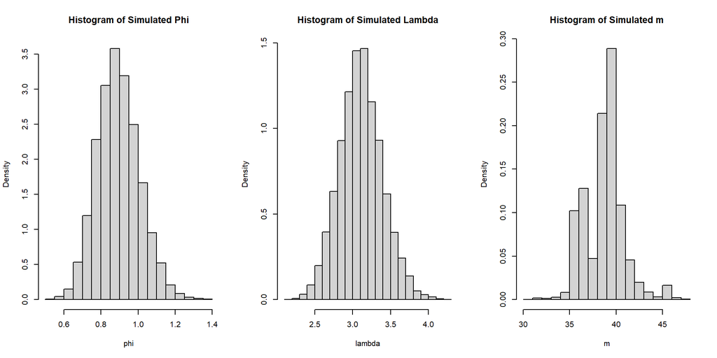

```r
par(mfrow=c(1,3))
hist(phi[(burnin + 1):Nsim], prob = T, xlab = 'phi', main = 'Histogram of Simulated Phi')
hist(lambda[(burnin + 1):Nsim], prob = T, xlab = 'lambda', main = 'Histogram of Simulated Lambda')
hist(m[(burnin + 1):Nsim], prob = T, xlab = 'm', main = 'Histogram of Simulated m')
```

### Question3

Analyse the convergence of the chains with at least two tools

Method1: acf to observe the convergence

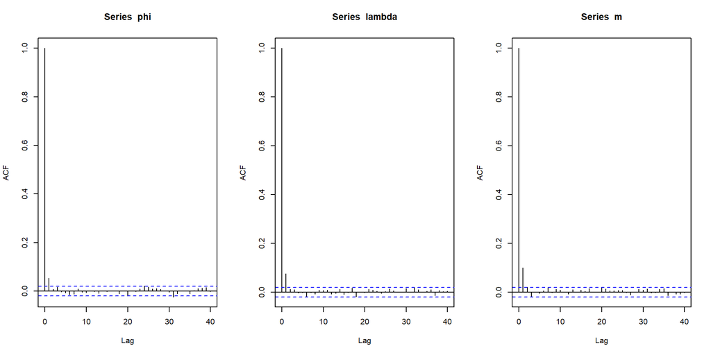

```r
par(mfrow=c(1,3))
acf(phi)
acf(lambda)
acf(m)
```

We can tell from autocorrelation plot that all three variables converged since the autocorrelation is low as number of simulation increases and drops to close to zero quickly.

Method2: multiple chain method

Now we make a function of Gibbs sampler that takes hyperparaemters as arguments.

```r
gibbs_sampler <- function(alpha, beta, a, b) {
    lambda = phi = m = rep(0, Nsim) #init arrays
    m[1] = 60
    lambda[1] = rgamma(1, shape = alpha + sum_y[m[1]], rate = m[1] + beta)
    phi[1] = rgamma(1, shape = a + sum_y[n] - sum_y[m[1]], rate = n - m[1] + b)
    zz = 0
    z = (1:(n - 1))
    for (k in 1:(n - 1)) {
        z[k] = exp((phi[1] - lambda[1]) * k) * (lambda[1] / phi[1]) ^ (sum_y[k])
        zz = zz + exp((phi[1] - lambda[1]) * k) * (lambda[1] / phi[1]) ^ (sum_y[k])
    }
    prob = z / zz
    m[1] = sample(n-1, 1, replace = TRUE, prob)

    for (i in 2:Nsim) {
        lambda[i] = rgamma(1, shape = alpha + sum_y[m[i - 1]], rate = m[i - 1] + beta)
        phi[i] = rgamma(1, shape = a + sum_y[n] - sum_y[m[i - 1]], rate = n - m[i - 1] + b)
        zz = 0
        z = (1:(n - 1))
        for (k in 1:(n - 1)) {
            z[k] = exp((phi[i] - lambda[i]) * k) * (lambda[i] / phi[i]) ^ (sum_y[k])
            zz = zz + exp((phi[i] - lambda[i]) * k) * (lambda[i] / phi[i]) ^ (sum_y[k])

        }
        prob = z / zz
        m[i] = sample(n-1, 1, replace = TRUE, prob)
    }
    return(list(lambda=lambda, phi=phi, m=m))
}
```

Now we experiment 3 gibbs sampling with different hyperparameters

```r
samples1 = gibbs_sampler(alpha=1, beta=1, a=2, b=2)
samples2 = gibbs_sampler(alpha=1, beta=2, a=10, b=20)
samples3 = gibbs_sampler(alpha=1, beta=3, a=8, b=5)
```

```r
# combine results of lambda
lambdas = cbind(samples1$lambda, samples2$lambda, samples3$lambda)
df_lambda = as.data.frame(lambdas)
colnames(df_lambda) = c('lambda1', 'lambda2', 'lambda3')
df_lambda$x = seq.int(nrow(df_lambda))

# combine results of phi
phis = cbind(samples1$phi, samples2$phi, samples3$phi)
df_phi = as.data.frame(phis)
colnames(df_phi) = c('phi1', 'phi2', 'phi3')
df_phi$x = seq.int(nrow(df_phi))

# combine results of m
ms = cbind(samples1$m, samples2$m, samples3$m)
df_m = as.data.frame(ms)
colnames(df_m) = c('m1', 'm2', 'm3')
df_m$x = seq.int(nrow(df_m))

# we only take raws after burinin peiord
df_lambda = slice(df_lambda, burnin+1: Nsim)
df_phi = slice(df_phi, burnin+1:Nsim)
df_m = slice(df_m, burnin+1:Nsim)
```

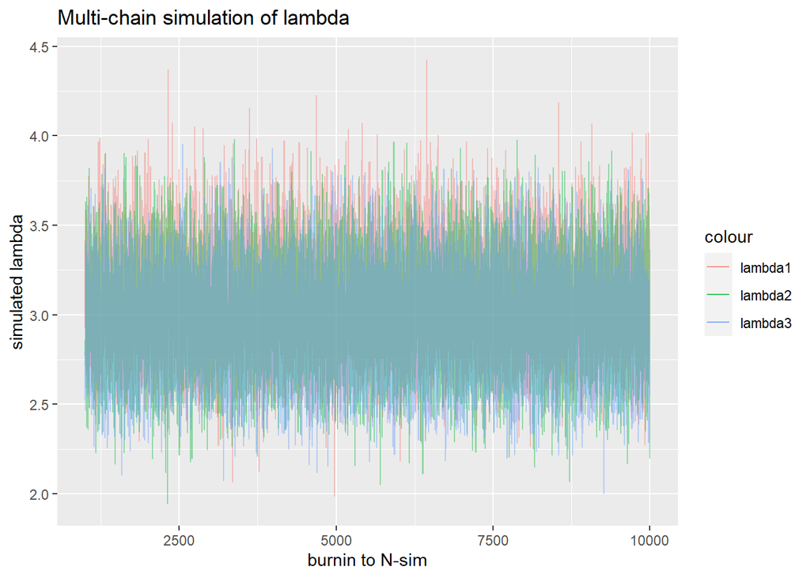

```r
# transparency parameter
alpha = 0.4

ggplot(df_lambda, aes(x=x)) +
    geom_line(aes(y=lambda1, color='lambda1'), alpha=alpha) +
    geom_line(aes(y=lambda2, color='lambda2'), alpha=alpha) +
    geom_line(aes(y=lambda3, color='lambda3'), alpha=alpha) +
    ggtitle('Multi-chain simulation of lambda') +
    xlab('burnin to N-sim') +
    ylab('simulated lambda')
```

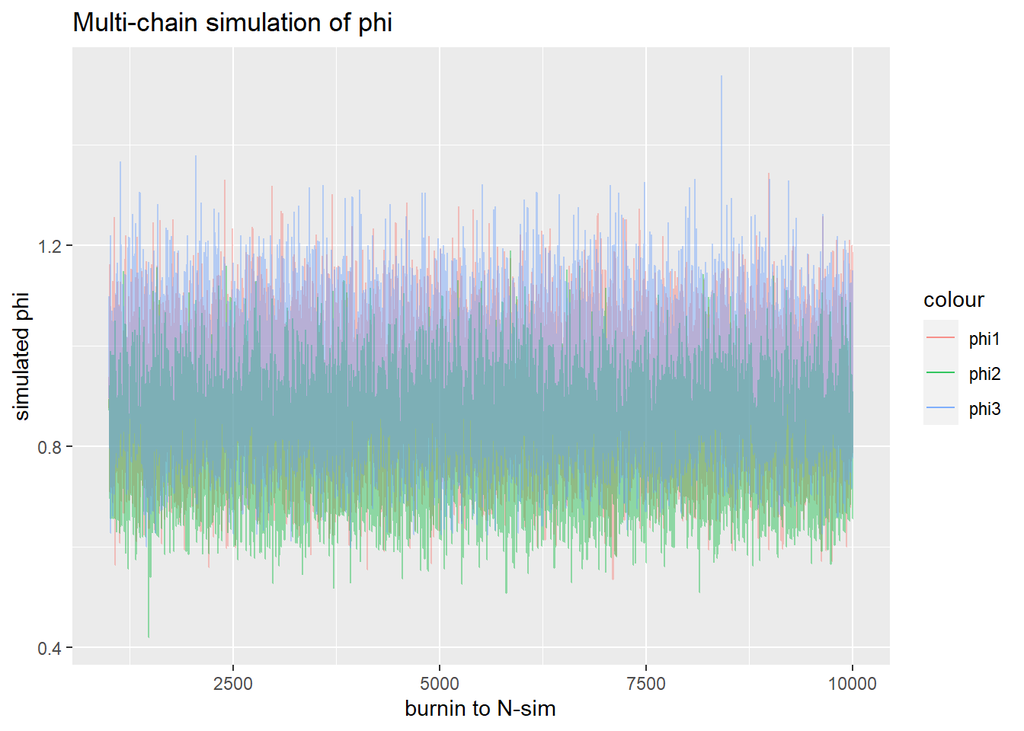

```r
ggplot(df_phi, aes(x=x)) +
    geom_line(aes(y=phi1, color='phi1'), alpha=alpha) +
    geom_line(aes(y=phi2, color='phi2'), alpha=alpha) +
    geom_line(aes(y=phi3, color='phi3'), alpha=alpha) +
    ggtitle('Multi-chain simulation of phi') +
    xlab('burnin to N-sim') +
    ylab('simulated phi')
```

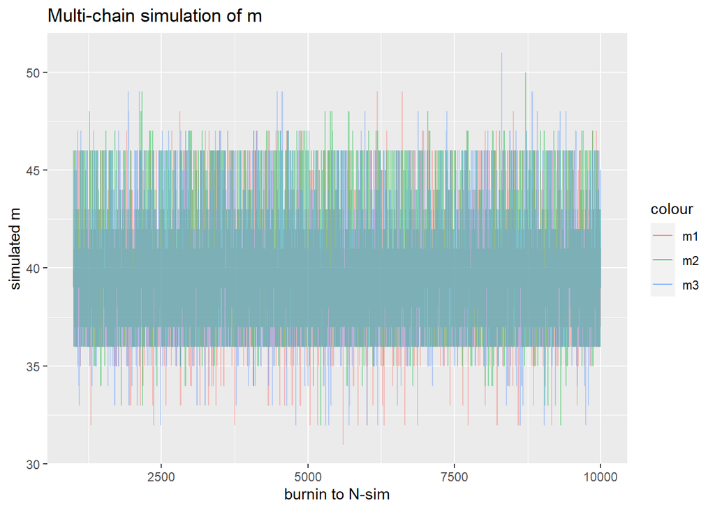

```r
ggplot(df_m, aes(x=x)) +
    geom_line(aes(y=m1, color='m1'), alpha=alpha) +
    geom_line(aes(y=m2, color='m2'), alpha=alpha) +
    geom_line(aes(y=m3, color='m3'), alpha=alpha) +
    ggtitle('Multi-chain simulation of m') +
    xlab('burnin to N-sim') +
    ylab('simulated m')
```

As we can see from the simulation plots, regardless of hyperparameter values, the simulation always converges to the same value.